# Lab Cars, Pt 1

Single predictor

Sean Xiong, Tony Lin, Charlotte Anderson, Evan Noronha

2018-10-16

**Due:** 2018-10-19 by 11:59PM

## Introduction

The purpose of this lab activity is to give you a chance to practice what you have learned about regression while getting familiar with the RStudio platform. I am assuming that much of this lab is review with a few new concepts interwoven.

# Packages

In this lab we will work with the `tidyverse` and `broom` packages. We can install and load them with the following:

When using a library for the first time, you need to run install.packages(“package name”). After the package is installed, you can load it using library(package name). For your convenience, commonly used libraries like tidyverse, moderndive, and openintro have been permanently installed in your R image.

```r
library(tidyverse)
library(moderndive)
```

# Data: Motor Trend Car Road Tests

## Description

The data was extracted from the 1974 Motor Trend US magazine, and comprises fuel consumption and 10 aspects of automobile design and performance for 32 automobiles (1973–74 models).

The data is a built in data set, meaning that after loading the above packages, it is loaded into your work space as *mtcars*.

```r
glimpse(mtcars)
```

```
## Observations: 32
## Variables: 11
## $ mpg  <dbl> 21, 21, 23, 21, 19, 18, 14, 24, 23, 19, 18, 16, 17, 15, 1...
## $ cyl  <dbl> 6, 6, 4, 6, 8, 6, 8, 4, 4, 6, 6, 8, 8, 8, 8, 8, 8, 4, 4, ...
## $ disp <dbl> 160, 160, 108, 258, 360, 225, 360, 147, 141, 168, 168, 27...
## $ hp   <dbl> 110, 110, 93, 110, 175, 105, 245, 62, 95, 123, 123, 180, ...
## $ drat <dbl> 3.9, 3.9, 3.9, 3.1, 3.1, 2.8, 3.2, 3.7, 3.9, 3.9, 3.9, 3....
## $ wt   <dbl> 2.6, 2.9, 2.3, 3.2, 3.4, 3.5, 3.6, 3.2, 3.1, 3.4, 3.4, 4....
## $ qsec <dbl> 16, 17, 19, 19, 17, 20, 16, 20, 23, 18, 19, 17, 18, 18, 1...
## $ vs   <dbl> 0, 0, 1, 1, 0, 1, 0, 1, 1, 1, 1, 0, 0, 0, 0, 0, 0, 1, 1, ...
## $ am   <dbl> 1, 1, 1, 0, 0, 0, 0, 0, 0, 0, 0, 0, 0, 0, 0, 0, 0, 1, 1, ...
## $ gear <dbl> 4, 4, 4, 3, 3, 3, 3, 4, 4, 4, 4, 3, 3, 3, 3, 3, 3, 4, 4, ...
## $ carb <dbl> 4, 4, 1, 1, 2, 1, 4, 2, 2, 4, 4, 3, 3, 3, 4, 4, 4, 1, 2, ...
```

## Codebook

| Variable name | Description |
| --- | --- |
| `mpg` | miles/(US) gallon |
| `cyl` | number of cylinders |
| `disp` | displacement (cu. in) |
| `hp` | gross horsepower |
| `drat` | rear axle ratio |
| `wt` | weight (1000 lbs) |
| `qsec` | 1/4 mile time |
| `vs` | engine (0 = v-shaped, 1 = straight) |
| `am` | transmission (0 = automatic, 1 = manual) |
| `gear` | number of forward gears |
| `carb` | number of carburetors |

# Exercises

## Part 1: Exploratory Data Analysis

**Hint:** histogram template code: data %>% ggplot(aes(x = xvar)) + geom_histogram() boxplot template code: data %>% ggplot(aes(y = yvar)) + geom_boxplot() summary stats template code (5-number summary + mean):  
data %>% summarize(min_xxx = min(var), Q1_xxx = quantile(var, 0.25),  
median_xxx = median(var), mean_xxx = mean(var), Q3_xxx = quantile(var, 0.75), max_xxx = max(var))

1. We want to build regression models to predict the fuel efficiency (mpg). Visualize the distribution of `mpg`. Is the distribution skewed? Is this what you expected to see? Why, or why not? Include any summary statistics and visualizations you use in your response.

**Answer:** **The distribution is right-skewed.This is what we expected because of the time period in which the data was collected. Cars are also not that efficient. The histogram below helped us in our response.**

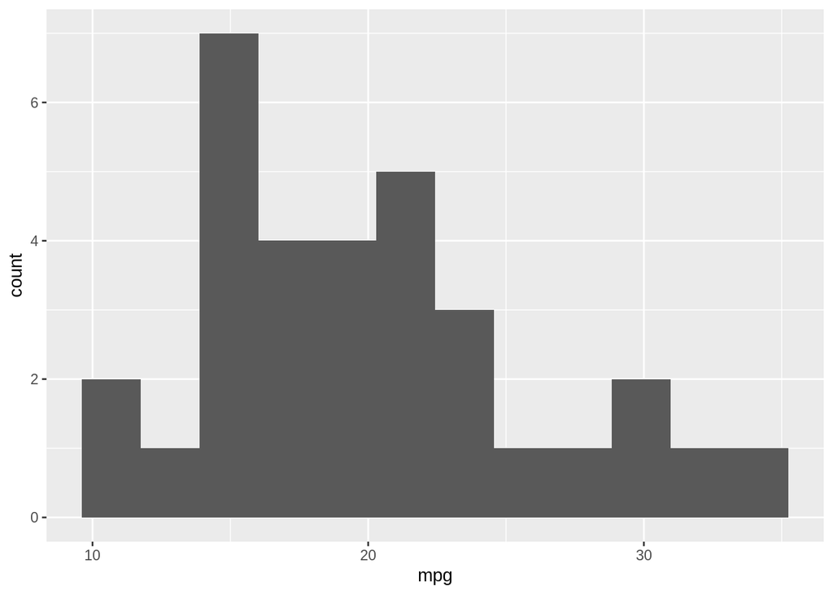

```r
mtcars %>% ggplot(aes(x = mpg)) + geom_histogram(bins = 12)
```

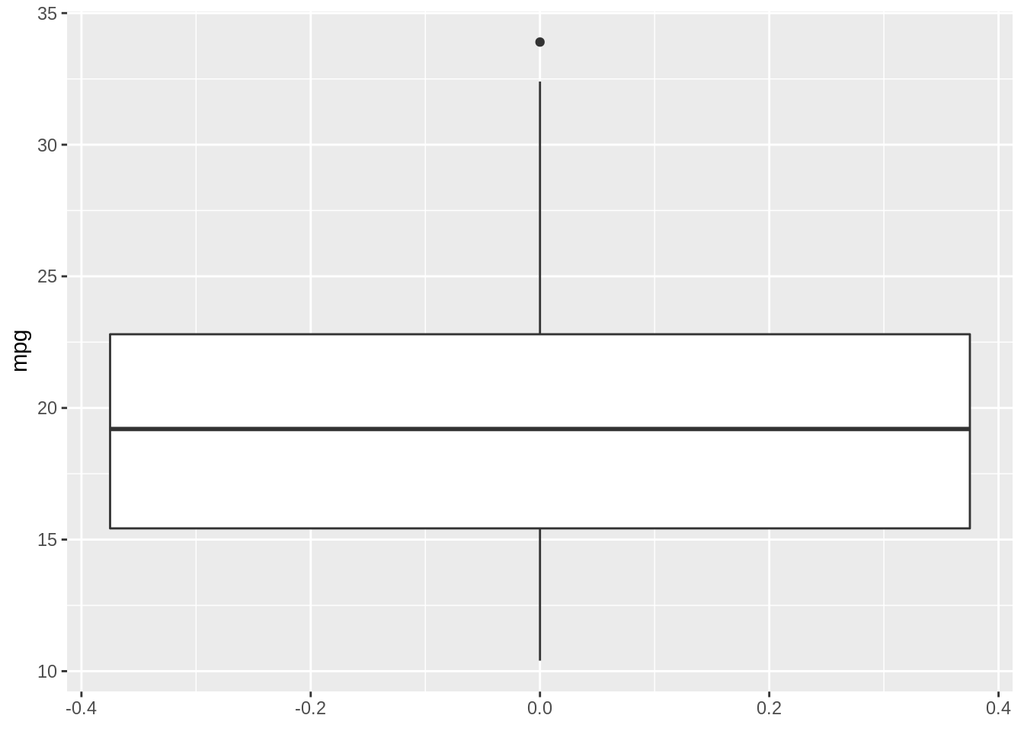

```r
mtcars %>% ggplot(aes(y = mpg)) + geom_boxplot()
```

```r
mtcars %>% summarize(min_mpg = min(mpg),
                    Q1_mpg = quantile(mpg, 0.25),
                    median_mpg = median(mpg),
                    mean_mpg = mean(mpg),
                    Q3_mpg = quantile(mpg, 0.75),
                    max_mpg = max(mpg))
```

```
##   min_mpg Q1_mpg median_mpg mean_mpg Q3_mpg max_mpg
## 1      10     15         19       20     23      34
```

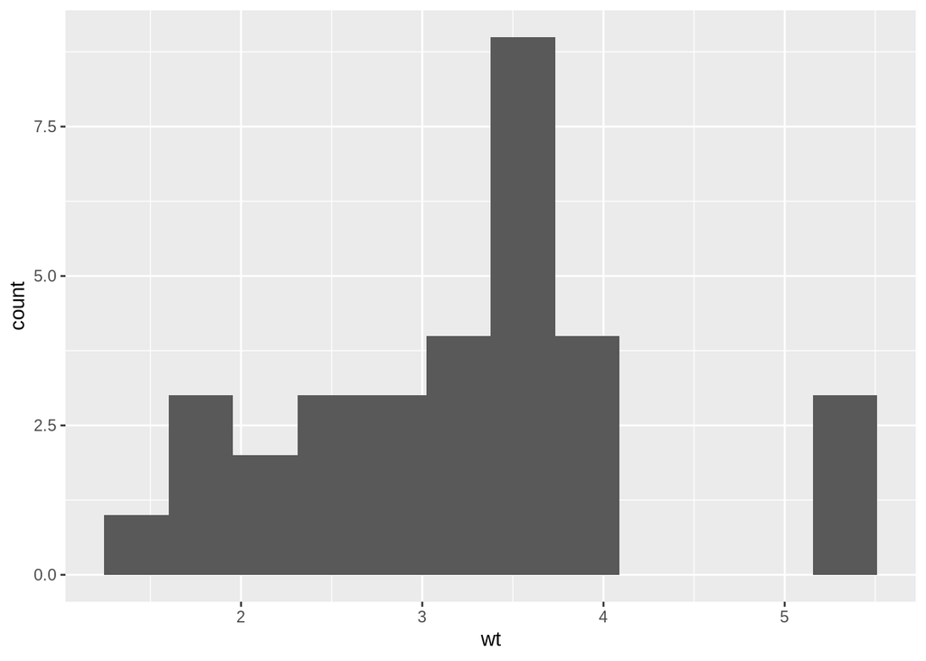

```r
mtcars %>% ggplot(aes(x = wt)) + geom_histogram(bins = 12)
```

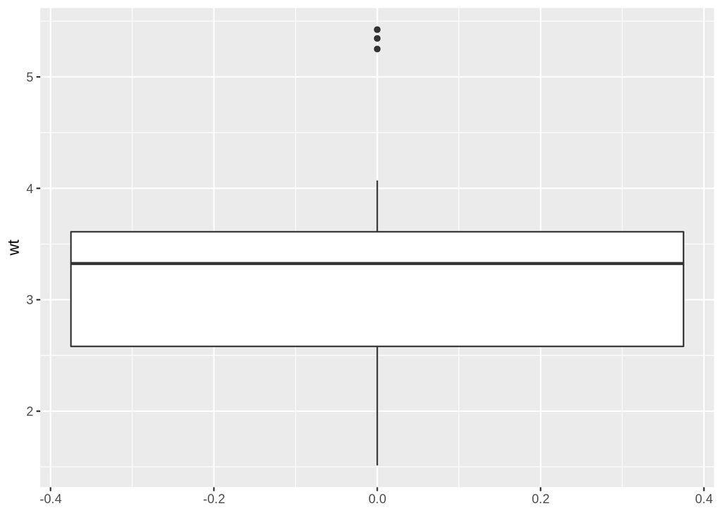

```r
mtcars %>% ggplot(aes(y =wt)) + geom_boxplot()
```

```r
mtcars %>% summarize(min_wt = min(wt),
                    Q1_wt = quantile(wt, 0.25),
                    median_wt = median(wt),
                    mean_wt = mean(wt),
                    Q3_wt = quantile(wt, 0.75),
                    max_wt = max(wt))
```

```
##   min_wt Q1_wt median_wt mean_wt Q3_wt max_wt
## 1    1.5   2.6       3.3     3.2   3.6    5.4
```

2. Visualize and describe the relationship between `mpg` and the `wt` of the cars. Is this relationship linear? What is the direction of the relationship? Do there seem to be observations that do not seem to fit the general pattern of the others?

**Answer:** **We visualized that the heavier the car the less miles per gallon. Yes, it has a linear relationship. The direction was negative or decreasing. No, the data seems to fit the general pattern.**

**Hint:** data %>% ggplot(aes(x = xvar, y = yvar)) + geom_point()

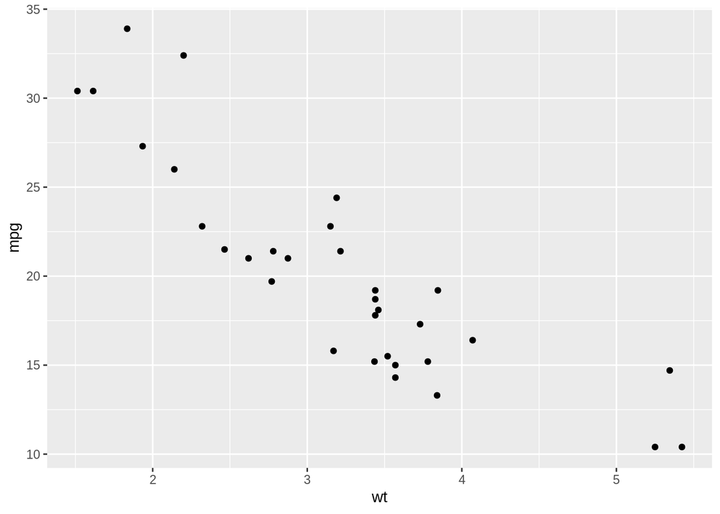

```r
 mtcars %>% ggplot(aes(x = wt, y = mpg)) + geom_point()
```

3. Calculate the *correlation coefficient* between `mpg` and `wt`. Discuss how this statistic relates to your comments for the questions above.

**Answer:** **The correlation coefficient is -0.868. The relationship is fairly is fairly strong. The statistics relates to our comments because the graph is going at a negative value. We predicted it to have a decreasing value.**

**Hint:** data %>% get_correlation(response_var ~ predictor_var)

```r
mtcars %>% get_correlation(mpg ~ wt)
```

```
## # A tibble: 1 x 1
##   correlation
##         <dbl>
## 1      -0.868
```

## Part 3: Linear regression with a numerical predictor

A prediction equation for a linear model is in the form $\hat{y} = b_0 + b_1 x$. This is an estimate to the population regression equation $y = \beta_0 + \beta_1 x + \epsilon$ *To fit a simple regression model:  
model_xxx <- lm(response ~ predictor, data) get_regression_table(model_xxx) # provides parameter estimates with confidence intervals get_regression_summaries(model_xxx) # provides model fit summary

4. Let’s see if the apparent trend in the plot is something more than natural variation. Fit a linear model called `model_mpg` to predict average fuel efficiency `mpg` by the weight of the car (`wt`). Based on the regression output, write the linear model.

**Answer:**

```r
model_mpg <- lm(mpg ~ wt, data = mtcars)
get_regression_table(model_mpg)
```

```
## # A tibble: 2 x 7
##   term      estimate std_error statistic p_value lower_ci upper_ci
##   <chr>        <dbl>     <dbl>     <dbl>   <dbl>    <dbl>    <dbl>
## 1 intercept    37.3      1.88      19.9        0    33.4     41.1
## 2 wt           -5.34     0.559     -9.56       0    -6.49    -4.20
```

**mpg_hat = 37.3 - 5.3(wt)**

**Hint:** data %>% ggplot(aes(x = xvar, y = yvar)) + geom_point() + geom_smooth(method = “lm”, se = TRUE/FALSE, color = " “)

5. Re-plot your visualization from Exercise 3, and add the regression line to this plot in orange color. Turn off the shading for the uncertainty of the line.

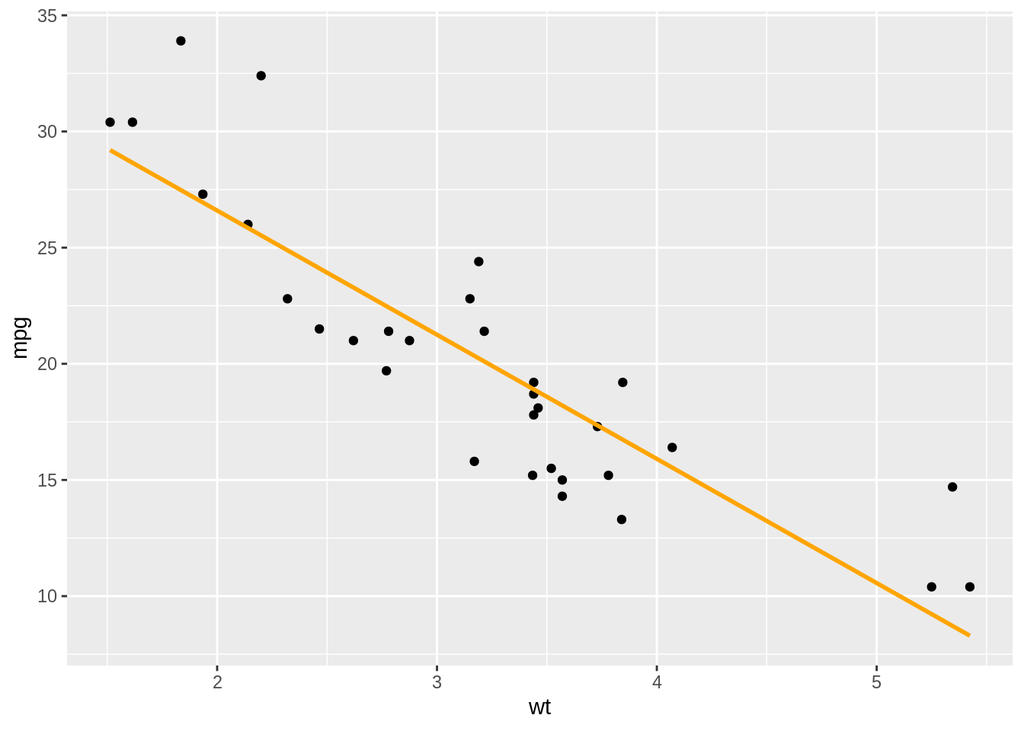

```r
 mtcars %>% ggplot(aes(x = wt, y = mpg)) +
            geom_point() +
           geom_smooth(method = "lm", se = FALSE, color = "orange")
```

6. Interpret the slope of the linear model in context of the data.

**Answer:** **The slope is negative. As the weight of the car increases(by 1,000 lbs), the mpg decreases by 5.3.**

7. Does this model provide evidence of a statistically significant relationship between `mpg` and `wt`? Answer the question and explain how you are determining your answer.

**Answer:** **Our wonderful team believes that the interval between (-6.5, -4.2) represents a range of plausible values for the slope parameter beta_1. We also agreed that 0 isn’t a plausible value, thus leading to a real relationship between mpg and wt.**

8. Find and interpret a confidence interval for the slope parameter.

**Answer: For every increase in 1 wt (1000 lbs) there is a decrease in mpg between 4.2 and 6.5.**

9. Interpret the intercept of the linear model in context of the data. Comment on whether or not the intercept makes sense in this context.

**Answer: The intercept would be 37.3 but this would not make sense because there aren’t any cars that weigh nothing.**

10. Determine the $R^2$ of the model and interpret it in context of the data. Comment on which models are being compared by the $R^2$ value. Does this seem like a good model?

**Answer:** **R^(2) is 0.75 in our data which seems pretty good because its 75% accurate. How good the model is, really depends on the data’s application.**

```r
get_regression_summaries(model_mpg)
```

```
## # A tibble: 1 x 8
##   r_squared adj_r_squared   mse  rmse sigma statistic p_value    df
##       <dbl>         <dbl> <dbl> <dbl> <dbl>     <dbl>   <dbl> <dbl>
## 1     0.753         0.745  8.70  2.95  3.05      91.4       0     2
```

11. Consider the observation (car) weight approximately 5250 lbs and having a fuel efficiency close to 10 mpg. Classify this observation as: high/low leverage and high/low influence.

**Answer:** **The observation for this car is of high leverage and therefore, having high influence. There is a big difference between the last point(weight of car) at 4.1 and then 5.2.**

12. Consider the observation (car) weight approximately 3750 lbs and having a fuel efficiency close to 17.5 mpg. Classify this observation as: high/low leverage and high/low influence.

**Answer:** **The observation for this car is of low leverage and low influence. The approx. weight and mpg values are in between common values in the given data set.**

13. What is the ‘danger’ with influential observations when fitting regression models? Use the output of the code below to help answer the question above? (Remove `eval=FALSE` from the chunk below to compile)

**Answer:** **The danger with influential observations is that they skew the data. The data model with the freak observation had its value ranges (slope) change as compared to the original model.**

```r
#Create new freak observation
mtcars_extra_obs <- data_frame(mpg = 35,
                               cyl = 8,
                               disp = 400,
                               hp = 300,
                               drat = 3.9,
                               wt = 5.25,
                               qsec = 15,
                               vs = 1,
                               am = 1,
                               gear = 4,
                               carb = 9)

# Add freak observation and run same model
mtcars_extra <- bind_rows(mtcars, mtcars_extra_obs)
model_mpg_extra <- lm(mpg ~ wt, mtcars_extra)
get_regression_table(model_mpg_extra)
```

```
## # A tibble: 2 x 7
##   term      estimate std_error statistic p_value lower_ci upper_ci
##   <chr>        <dbl>     <dbl>     <dbl>   <dbl>    <dbl>    <dbl>
## 1 intercept    33.1       3.09     10.7        0    26.8     39.4
## 2 wt           -3.84      0.9      -4.26       0    -5.67    -2.00
```

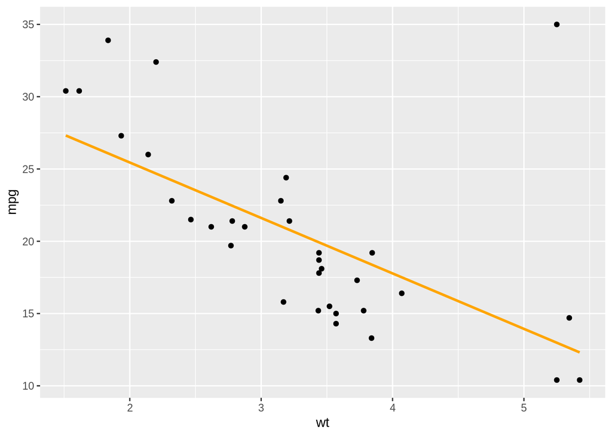

```r
mtcars_extra %>% ggplot(aes(x = wt, y = mpg)) +
                 geom_point() +
                 geom_smooth(method = 'lm',
                             se = FALSE,
                             color = 'orange')
```

Now, forget about the extra observation we added to the data set. Use `mtcars` to answer the following.

14. What is a range of plausible values for the average `mpg` for cars weighing 3,500 lbs?

**Answer:** **The range of plausible values for the average ‘mpg’ of a car weighing 3,500 lbs is between 17 and 20 mpg.**

```r
# Example code
# new_obs <- data_frame(wt = #insert number)
#
# # use interval = 'confidence' for a confidence interval for the average response at a particular value of x             # use interval = 'prediction' for a prediction interval for response at a particular value of x
# predict(model_mpg, newdata = new_obs, interval = 'confidence')
```

```r
# Example code
new_obs <- data_frame(wt = 3.5)
predict(model_mpg, newdata = new_obs, interval = 'confidence')
```

```
##   fit lwr upr
## 1  19  17  20
```

15. What is a range of plausible values for the fuel efficiency `mpg` of a car weighing 4,000 lbs?

**Answer:** **The range of plausible values for the ‘mpg’ of a car weighing 4,000 lbs is between 9.5 and 22 mpg.**

```r
new_obs <- data_frame(wt = 4)
predict(model_mpg, newdata = new_obs, interval = 'prediction')
```

```
##   fit lwr upr
## 1  16 9.5  22
```

**Answer:** **“Because averages by definition weigh less then individual observations” - Lossing**

## Part 4: Linear regression with a categorical predictor

When fitting a regression model with a categorical predictor we need to make use of indicator functions.

*Indicator functions* are a special function that are either ‘On’ (when the function is equal to one) or ‘Off’ (when the function is equal to zero). We use the bold-face $1_{\text{logical condition}}$ to indicate that we are using an indicator function. The appropriate mathematical definition is:

$$1_{\text{Logical Condition}} =\begin{cases}
1, \text{if Condition is TRUE}\\
0, \text{if Condition is FALSE}\\
\end{cases}$$

Below, we are going to fit a regression model to predict the fuel efficiency `mpg` from the transmission type `am`. The population regression equation can be written as: $mpg = \beta_0 + \beta_1 1_{\text{manual}} + \epsilon$. The indicator function $1_{\text{manual}}$ evaluates to zero for automatic transmission cars and evaluates to one for manual transmission cars.

Thus, there are really 2 equations corresponding to manual and automatic transmission cars:

For automatic transmissions we have: $mpg = \beta_0 + \beta_1 * 0 + \epsilon = \beta_0 + \epsilon$

For manual transmissions we have: $mpg = \beta_0 + \beta_1 * 1 + \epsilon = (\beta_0 + \beta_1) + \epsilon$

17. Fit a new linear model called `model_vs` to predict average fuel efficiency `mpg` based on `am` transmission type (manual or automatic).

```r
mtcars <- mtcars %>% mutate(am = if_else(am == 1, "manual", "automatic"))
model_am <- lm(mpg ~ am, mtcars)
get_regression_table(model_am)
```

```
## # A tibble: 2 x 7
##   term      estimate std_error statistic p_value lower_ci upper_ci
##   <chr>        <dbl>     <dbl>     <dbl>   <dbl>    <dbl>    <dbl>
## 1 intercept    17.1       1.12     15.2        0    14.9      19.4
## 2 ammanual      7.24      1.76      4.11       0     3.64     10.8
```

18. What is the equation of the line predicting fuel efficiency (in `mpg`) corresponding to manual transmission cars? Automatic transmission cars?

**Answer:** **Mpg_hat = 17.1 + 7.24 1(manual)**

19. Based on the regression output, interpret the slope (not a true slope) and intercept in context of the data.

**Answer:** **Based on the output, our y-intercept could range from 14.9 to 19.4, which is the mpg for automatic cars.The slope could range from 3.64 to 10.8, and this is the range for mpg that can be added to manual cars.Based on our equation in 17, we can see that the average mpg for manual transmission is 7.24 higher than average automatic transmission mpg.**

20. We have encountered situations previously where the intercept may not have a sensical interpretation. Why is the intercept in this model interpretable?

**Answer:** **The y-intercept represents the average fuel efficiency for automatic transmission cars, it is direclty interpretable. It will always be in the model.**

21. Find and interpret a confidence interval for the ‘slope’ parameter.

**Answer:** **(3.64,10.8) We can see that the average mpg for manuel transmission is between 3.64 and 10.8 higher than average automatic transmission mpg.**

22. Below, the `predict()` function was used to obtain the intervals below. Interpret each interval. Be very clear about what the big difference is for each interval.

**Answer:** **The average fuel efficiency for automatic cars is between 15 and 19 mpg.If we were to sample a new car, based on the regression model we can expect the fuel efficiency to be between 6.9 to 27 mpg.**

```r
# Example code
new_obs <- data_frame(am = 'automatic')
predict(model_am, newdata = new_obs, interval = 'confidence')
```

```
##   fit lwr upr
## 1  17  15  19
```

```r
predict(model_am, newdata = new_obs, interval = 'prediction')
```

```
##   fit lwr upr
## 1  17 6.9  27
```

## Non-linear Relationships

Consider the following two scatterplots. Which one seems to fit better?

**Answer:** **The scatterplot at the bottom fits better. The points are more compact and fits better to the linear line then the one above.**

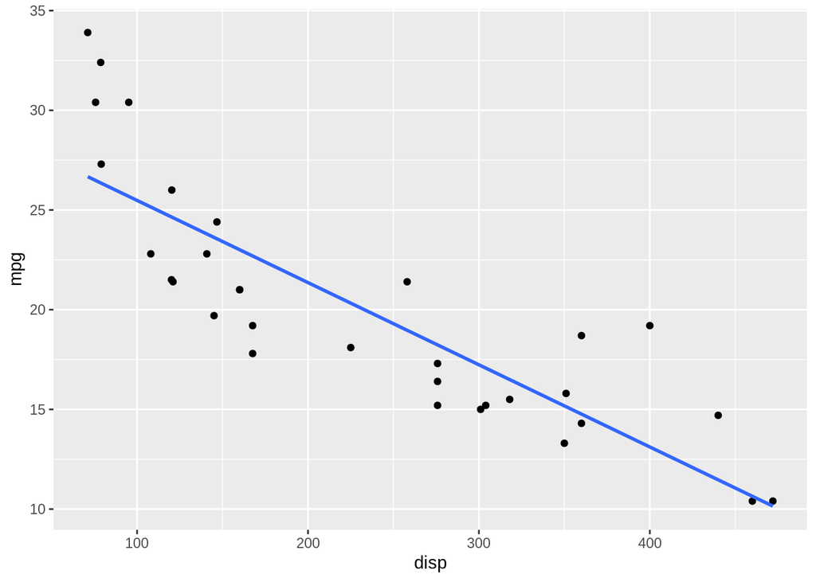

```r
mtcars %>% ggplot(aes(x = disp, y = mpg)) + geom_point() + geom_smooth(method = 'lm', se = FALSE)
```

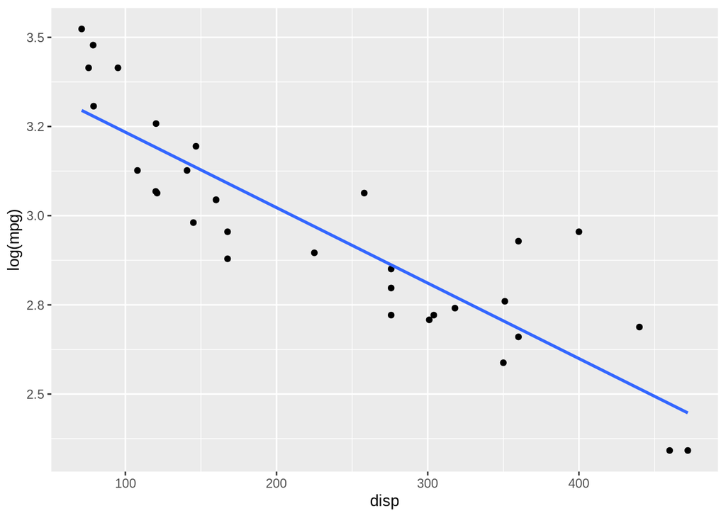

```r
mtcars %>% ggplot(aes(x = disp, y = log(mpg))) + geom_point() + geom_smooth(method = 'lm', se = FALSE)
```

23. Fit a linear model called `model_disp` to predict average log(fuel efficiency) `log(mpg)` by the displacement of the engine `disp`. Based on the regression output, write the fitted linear model.

```r
model_disp <- lm(log(mpg) ~ disp, data = mtcars)
get_regression_table(model_disp)
```

```
## # A tibble: 2 x 7
##   term      estimate std_error statistic p_value lower_ci upper_ci
##   <chr>        <dbl>     <dbl>     <dbl>   <dbl>    <dbl>    <dbl>
## 1 intercept    3.45      0.054      63.5       0    3.34     3.56
## 2 disp        -0.002     0         -10.2       0   -0.003   -0.002
```

**Answer:** **Log(mpg)=3.446-.002(disp)**

24. Interpret the slope coefficient in context.

**Answer:** **The slope coefficient is -0.002. Each additional cubic inch in displacement is associated in the decrease of log fuel efficiency of 0.002.**

25. Transform your prediction equation so that is is not on the log scale. (Hint: use exp() to when writing exponentials)

**Answer:** **Mpg_hat = exp(3.446 - 0.002 disp)**

In R, the exponential function is `exp()` Example: e^3 is exp(3)

26. What is a range of plausible values for the average fuel efficiency of cars having 300 cubic inches of displacement `disp`? What is a range of plausible values for the fuel efficiency of a car having 300 cubic inches of displacement `disp`? (Hint: you need to transform you interval so that they are not on the log scale.)

**Answer:** **The range of plausible values for the average fuel efficiency of cars having 300 cubic inches of displacement is between 16 and 18 mpg. The range of plausible values for a car thats 300 cubic inches of displacement is between 12 and 22 mpg.**

```r
new_obs <- data_frame(disp = 300)

exp(predict(model_disp, newdata = new_obs, interval = 'confidence' ))
```

```
##   fit lwr upr
## 1  17  16  18
```

```r
exp(predict(model_disp, newdata = new_obs, interval = 'prediction' ))
```

```
##   fit lwr upr
## 1  17  12  22
```